PREDICTING CREDIT CARD CHURNERS USING MACHINE LEARNING  
Damilola Odunuga  
March 8th, 2023

**INTRODUCTION**  
According to U.S.News (March, 2022), Credit card companies frequently advertise substantial welcome incentives in order to entice new clients. These welcome incentives can quickly earn a large number of miles, points, or cash back. Credit card churning is the practice of applying for cards with the purpose of canceling, downgrading, or “sock-drawering” the card after the spending requirements have been completed. Most credit cards demand you to spend a certain amount in a short period of time in order to qualify for these incentives.

BENEFIT OF CREDIT CARD CHURNING  
The benefits of credit card churning include welcome bonuses which customers enjoy, co-branded benefits from partners like airlines, exclusive benefit from hotel bookings, 0% APR intro offer usually between 12 to 21 months and waived annual fees offered by most credit card companies as an incentives.

DISADVANTANGES OF CREDIT CARD CHURNING  
Some disadvantages of credit card churning include overspending, high annual fees, keeping track of cards, harm to bank relationship, not earning the welcome bonus as a result of not spending the required amount.  
Another disadvantages or effect of credit card churning include payment history, utilization ratio, average age of credit, mix of credit, new credits. Banks can limit credit card churning through numerous ways. However, for this analysis, we would employ the use of machine learning to predict customers who are likely to churn their credit cards, using the bank credit card dataset available in Kaggle.

To complete this analysis, the first step is to perform exploratory data analysis, data cleaning on the data set of use, then the data will be split into 75% training and 25% test set, after which machine learning will be used to predict the customers credit card churners.

**EXPLORATORY DATA ANALYSIS**  
Some of the main factors to consider for customer churning are customer age and credit limit, this summary generated interquartile range of the two variables which include mean and median.

```
##    Min. 1st Qu.  Median    Mean 3rd Qu.    Max.
##   26.00   41.00   46.00   46.33   52.00   73.00
```

```
##    Min. 1st Qu.  Median    Mean 3rd Qu.    Max.
##    1438    2555    4549    8632   11068   34516
```

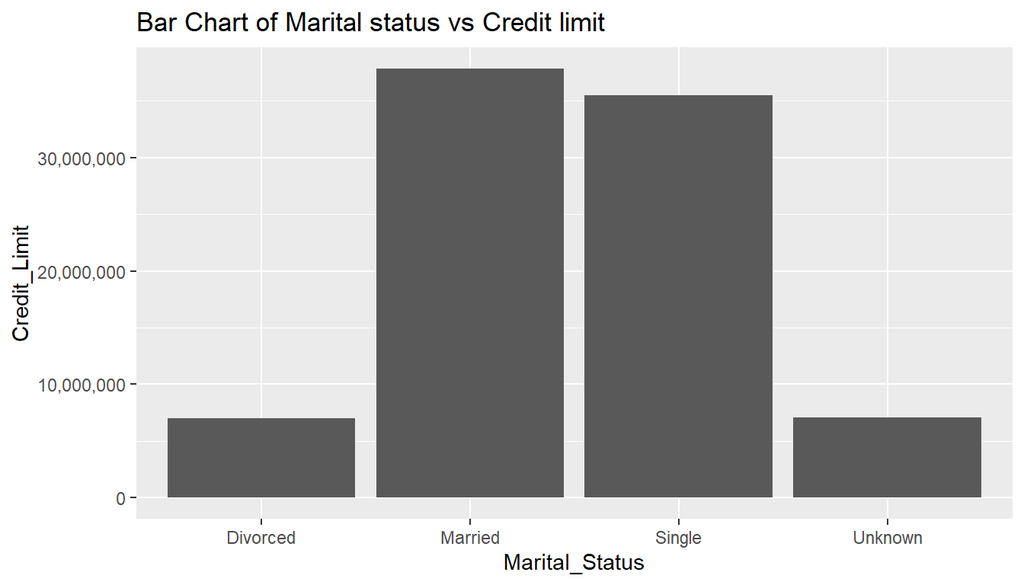

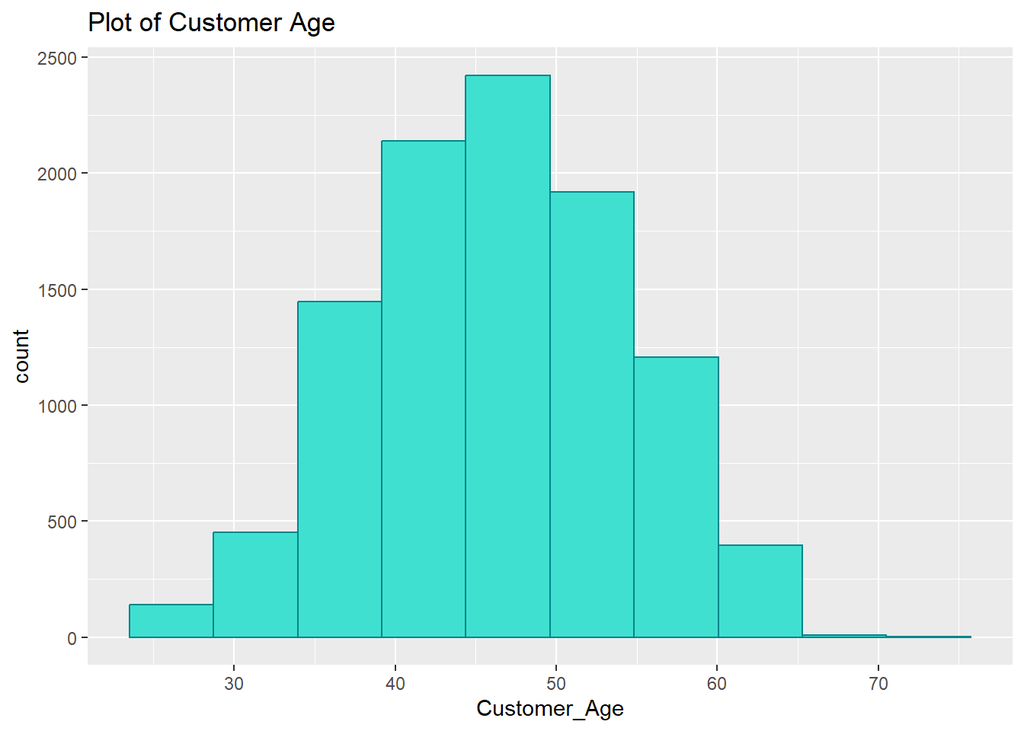

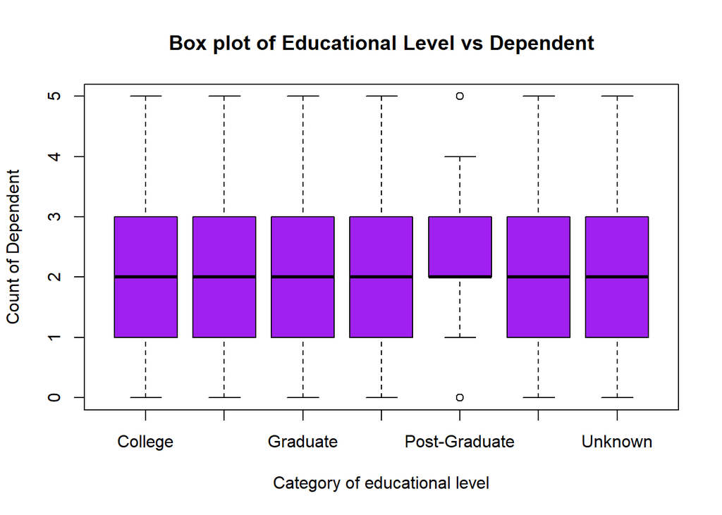

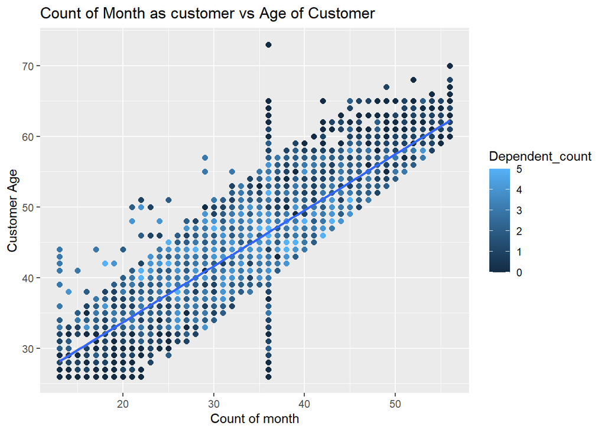

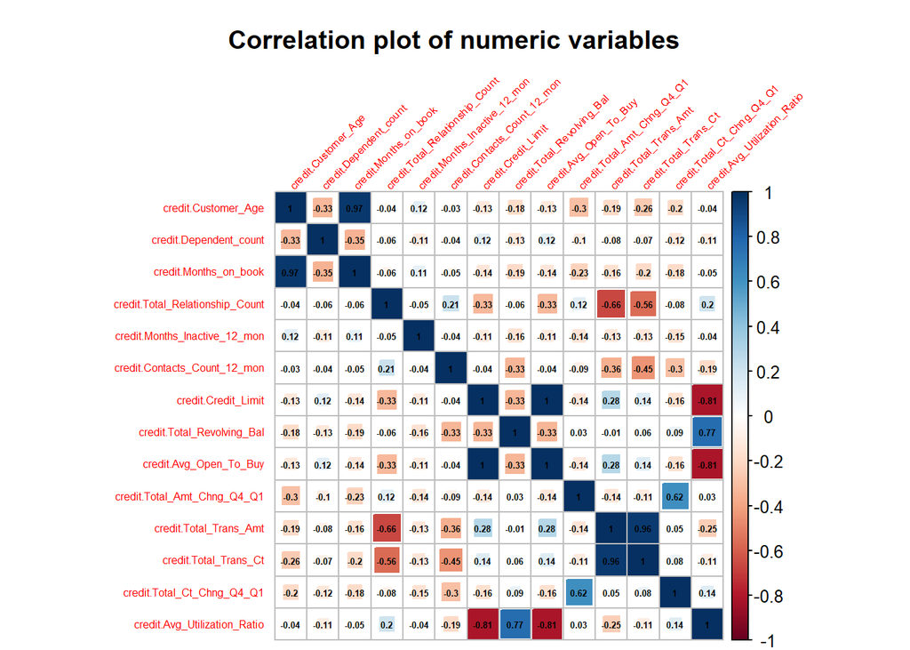

**DATA CLEANING**  
Missing or incorrect values in the dataset will change the outcome and might have an impact on the business decision. To prevent losses, difficulties and additional costs brought on by inaccurate data, the data must be correct. To accurately predict customer churning, the data will be cleaned by removing missing values, incorrect columns or rows, and columns which will not used for the predictive modeling.

1.1. FINDING NA’s AND DATA TYPE  
The data set does not contain any missing value (code chuck and result excluded), however, from the above box plot, the data shows few outliers which will not be removed from this analysis. Additionally, data type for all columns has been generated.

```
## spc_tbl_ [10,127 × 23] (S3: spec_tbl_df/tbl_df/tbl/data.frame)
##  $ CLIENTNUM                                                                                                                         : num [1:10127] 7.69e+08 8.19e+08 7.14e+08 7.70e+08 7.09e+08 ...
##  $ Attrition_Flag                                                                                                                    : chr [1:10127] "Existing Customer" "Existing Customer" "Existing Customer" "Existing Customer" ...
##  $ Customer_Age                                                                                                                      : num [1:10127] 45 49 51 40 40 44 51 32 37 48 ...
##  $ Gender                                                                                                                            : chr [1:10127] "M" "F" "M" "F" ...
##  $ Dependent_count                                                                                                                   : num [1:10127] 3 5 3 4 3 2 4 0 3 2 ...
##  $ Education_Level                                                                                                                   : chr [1:10127] "High School" "Graduate" "Graduate" "High School" ...
##  $ Marital_Status                                                                                                                    : chr [1:10127] "Married" "Single" "Married" "Unknown" ...
##  $ Income_Category                                                                                                                   : chr [1:10127] "$60K - $80K" "Less than $40K" "$80K - $120K" "Less than $40K" ...
##  $ Card_Category                                                                                                                     : chr [1:10127] "Blue" "Blue" "Blue" "Blue" ...
##  $ Months_on_book                                                                                                                    : num [1:10127] 39 44 36 34 21 36 46 27 36 36 ...
##  $ Total_Relationship_Count                                                                                                          : num [1:10127] 5 6 4 3 5 3 6 2 5 6 ...
##  $ Months_Inactive_12_mon                                                                                                            : num [1:10127] 1 1 1 4 1 1 1 2 2 3 ...
##  $ Contacts_Count_12_mon                                                                                                             : num [1:10127] 3 2 0 1 0 2 3 2 0 3 ...
##  $ Credit_Limit                                                                                                                      : num [1:10127] 12691 8256 3418 3313 4716 ...
##  $ Total_Revolving_Bal                                                                                                               : num [1:10127] 777 864 0 2517 0 ...
##  $ Avg_Open_To_Buy                                                                                                                   : num [1:10127] 11914 7392 3418 796 4716 ...
##  $ Total_Amt_Chng_Q4_Q1                                                                                                              : num [1:10127] 1.33 1.54 2.59 1.4 2.17 ...
##  $ Total_Trans_Amt                                                                                                                   : num [1:10127] 1144 1291 1887 1171 816 ...
##  $ Total_Trans_Ct                                                                                                                    : num [1:10127] 42 33 20 20 28 24 31 36 24 32 ...
##  $ Total_Ct_Chng_Q4_Q1                                                                                                               : num [1:10127] 1.62 3.71 2.33 2.33 2.5 ...
##  $ Avg_Utilization_Ratio                                                                                                             : num [1:10127] 0.061 0.105 0 0.76 0 0.311 0.066 0.048 0.113 0.144 ...
##  $ Naive_Bayes_Classifier_Attrition_Flag_Card_Category_Contacts_Count_12_mon_Dependent_count_Education_Level_Months_Inactive_12_mon_1: num [1:10127] 9.34e-05 5.69e-05 2.11e-05 1.34e-04 2.17e-05 ...
##  $ Naive_Bayes_Classifier_Attrition_Flag_Card_Category_Contacts_Count_12_mon_Dependent_count_Education_Level_Months_Inactive_12_mon_2: num [1:10127] 1 1 1 1 1 ...
##  - attr(*, "spec")=
##   .. cols(
##   ..   CLIENTNUM = col_double(),
##   ..   Attrition_Flag = col_character(),
##   ..   Customer_Age = col_double(),
##   ..   Gender = col_character(),
##   ..   Dependent_count = col_double(),
##   ..   Education_Level = col_character(),
##   ..   Marital_Status = col_character(),
##   ..   Income_Category = col_character(),
##   ..   Card_Category = col_character(),
##   ..   Months_on_book = col_double(),
##   ..   Total_Relationship_Count = col_double(),
##   ..   Months_Inactive_12_mon = col_double(),
##   ..   Contacts_Count_12_mon = col_double(),
##   ..   Credit_Limit = col_double(),
##   ..   Total_Revolving_Bal = col_double(),
##   ..   Avg_Open_To_Buy = col_double(),
##   ..   Total_Amt_Chng_Q4_Q1 = col_double(),
##   ..   Total_Trans_Amt = col_double(),
##   ..   Total_Trans_Ct = col_double(),
##   ..   Total_Ct_Chng_Q4_Q1 = col_double(),
##   ..   Avg_Utilization_Ratio = col_double(),
##   ..   Naive_Bayes_Classifier_Attrition_Flag_Card_Category_Contacts_Count_12_mon_Dependent_count_Education_Level_Months_Inactive_12_mon_1 = col_double(),
##   ..   Naive_Bayes_Classifier_Attrition_Flag_Card_Category_Contacts_Count_12_mon_Dependent_count_Education_Level_Months_Inactive_12_mon_2 = col_double()
##   .. )
##  - attr(*, "problems")=<externalptr>
```

1.2. DATA TRANSFORMATION  
Data transformation is required to change categorical variables using one-hot encoding or label encoding before performing the predictive modeling. Columns which will be change include: attrition flag, gender, education level, marital status, and income category.

1.3. SUBSETTING DEPENDENT AND INDEPENDENT VARIABLES  
Since this analysis is to predict churning customers, the dependent variable will be attrition flag while other variables will be independent variables. Additionally, factors such as client number and card category will be dropped for this analysis to be performed. Furthermore, the dataset will be split into 75% training and 25% test set for the machine learning model.

**RANDOM FOREST REGRESSION METHOD**

```
##
## Call:
##  randomForest(formula = Attrition_Flag ~ ., data = credit_2, mtry = 3,      importance = TRUE, na.action = na.omit)
##                Type of random forest: regression
##                      Number of trees: 500
## No. of variables tried at each split: 3
##
##           Mean of squared residuals: 0.03301316
##                     % Var explained: 75.52
```

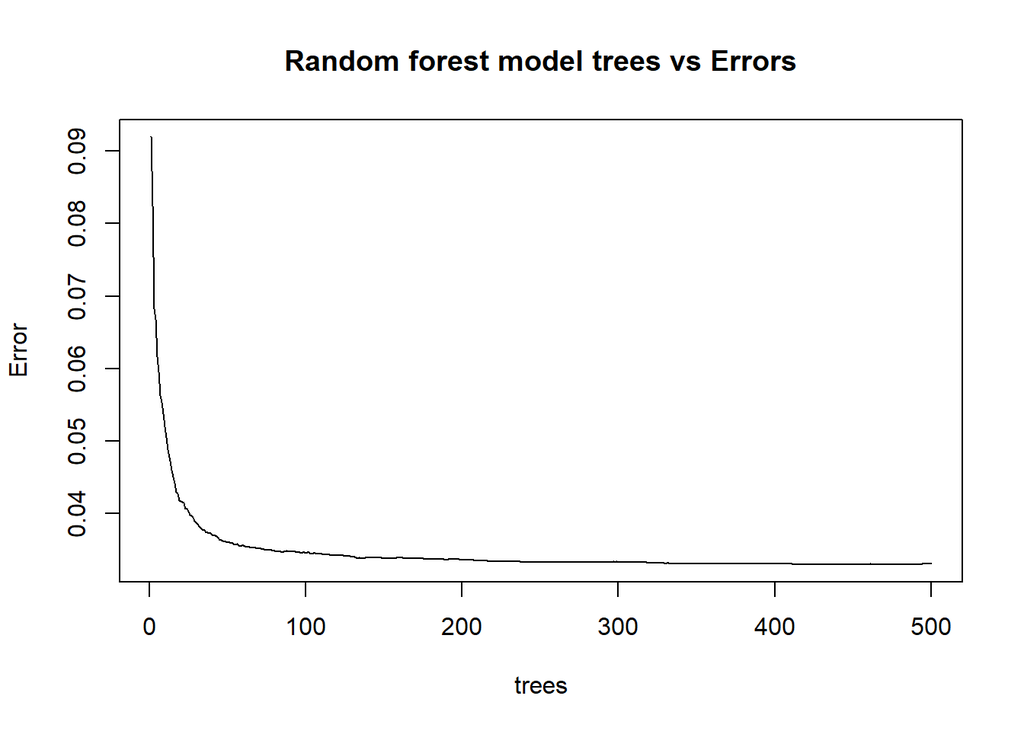

FEATURE IMPORTANCE

```
##                            %IncMSE IncNodePurity
## Customer_Age             32.884514      41.72013
## Gender                   18.410925      12.18238
## Dependent_count          12.574508      16.38877
## Education_Level           1.952100      14.78235
## Marital_Status           14.605215      12.22436
## Income_Category           6.794566      12.52345
## Months_on_book           22.584260      32.95059
## Total_Relationship_Count 59.704999      82.35766
## Months_Inactive_12_mon   29.143157      33.54648
## Contacts_Count_12_mon    28.621801      38.27940
## Credit_Limit             24.923380      45.69336
## Total_Revolving_Bal      36.276414     135.27599
## Avg_Open_To_Buy          22.467076      42.94997
## Total_Amt_Chng_Q4_Q1     47.960824      82.82941
## Total_Trans_Amt          66.061639     247.08741
## Total_Trans_Ct           69.372017     221.08186
## Total_Ct_Chng_Q4_Q1      52.666020     140.26690
## Avg_Utilization_Ratio    28.550275      90.75759
```

**RANDOM FOREST CLASSIFICATION METHOD**

```
##
## Call:
##  randomForest(formula = Attrition_Flag ~ ., data = train, proximity = TRUE,      importance = TRUE)
##                Type of random forest: classification
##                      Number of trees: 500
## No. of variables tried at each split: 4
##
##         OOB estimate of  error rate: 3.51%
## Confusion matrix:
##      0    1 class.error
## 0 6375   74  0.01147465
## 1  195 1017  0.16089109
```

PREDICTING TRAIN SET AND CONFUSION MATRIX

```
## Confusion Matrix and Statistics
##
##           Reference
## Prediction    0    1
##          0 6449    0
##          1    0 1212
##
##                Accuracy : 1
##                  95% CI : (0.9995, 1)
##     No Information Rate : 0.8418
##     P-Value [Acc > NIR] : < 2.2e-16
##
##                   Kappa : 1
##
##  Mcnemar's Test P-Value : NA
##
##             Sensitivity : 1.0000
##             Specificity : 1.0000
##          Pos Pred Value : 1.0000
##          Neg Pred Value : 1.0000
##              Prevalence : 0.8418
##          Detection Rate : 0.8418
##    Detection Prevalence : 0.8418
##       Balanced Accuracy : 1.0000
##
##        'Positive' Class : 0
##
```

PREDICTING TEST SET AND CONFUSION MATRIX

```
## Confusion Matrix and Statistics
##
##           Reference
## Prediction    0    1
##          0 2030   74
##          1   21  341
##
##                Accuracy : 0.9615
##                  95% CI : (0.9531, 0.9687)
##     No Information Rate : 0.8317
##     P-Value [Acc > NIR] : < 2.2e-16
##
##                   Kappa : 0.855
##
##  Mcnemar's Test P-Value : 9.55e-08
##
##             Sensitivity : 0.9898
##             Specificity : 0.8217
##          Pos Pred Value : 0.9648
##          Neg Pred Value : 0.9420
##              Prevalence : 0.8317
##          Detection Rate : 0.8232
##    Detection Prevalence : 0.8532
##       Balanced Accuracy : 0.9057
##
##        'Positive' Class : 0
##
```

FEATURE IMPORTANCE

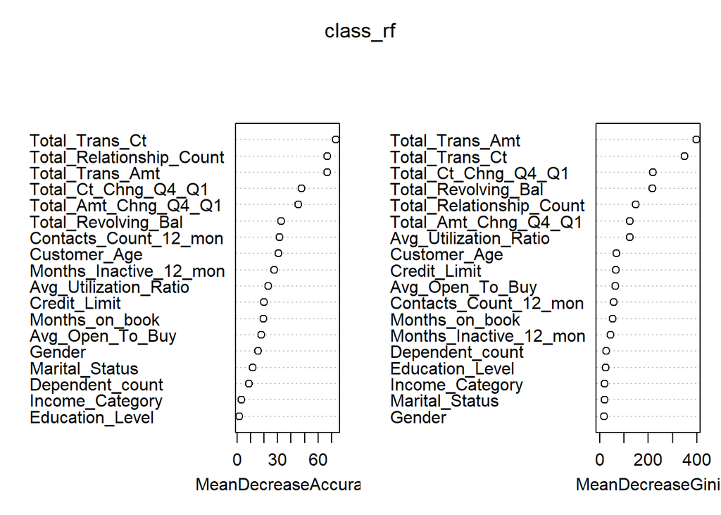

**SVM CLASSIFICATION MODEL**

```
##
## Call:
## svm(formula = Attrition_Flag ~ ., data = train, kernel = "linear",
##     scale = FALSE)
##
##
## Parameters:
##    SVM-Type:  C-classification
##  SVM-Kernel:  linear
##        cost:  1
##
## Number of Support Vectors:  1130
```

OPTIMAL COST OF CLASSIFICATION

```
##
## Call:
## best.tune(METHOD = svm, train.x = Attrition_Flag ~ ., data = train,
##     ranges = list(cost = c(0.001, 0.01, 0.1, 1, 5, 10, 100)), kernel = "linear")
##
##
## Parameters:
##    SVM-Type:  C-classification
##  SVM-Kernel:  linear
##        cost:  1
##
## Number of Support Vectors:  1823
```

PREDICTING TRAIN USING THE BEST MODEL

```
## Confusion Matrix and Statistics
##
##           Reference
## Prediction    0    1
##          0 6251  535
##          1  198  677
##
##                Accuracy : 0.9043
##                  95% CI : (0.8975, 0.9108)
##     No Information Rate : 0.8418
##     P-Value [Acc > NIR] : < 2.2e-16
##
##                   Kappa : 0.5951
##
##  Mcnemar's Test P-Value : < 2.2e-16
##
##             Sensitivity : 0.9693
##             Specificity : 0.5586
##          Pos Pred Value : 0.9212
##          Neg Pred Value : 0.7737
##              Prevalence : 0.8418
##          Detection Rate : 0.8160
##    Detection Prevalence : 0.8858
##       Balanced Accuracy : 0.7639
##
##        'Positive' Class : 0
##
```

PREDICTING TEST USING THE BEST MODEL

```
## Confusion Matrix and Statistics
##
##           Reference
## Prediction    0    1
##          0 2007  173
##          1   44  242
##
##                Accuracy : 0.912
##                  95% CI : (0.9001, 0.9229)
##     No Information Rate : 0.8317
##     P-Value [Acc > NIR] : < 2.2e-16
##
##                   Kappa : 0.6412
##
##  Mcnemar's Test P-Value : < 2.2e-16
##
##             Sensitivity : 0.9785
##             Specificity : 0.5831
##          Pos Pred Value : 0.9206
##          Neg Pred Value : 0.8462
##              Prevalence : 0.8317
##          Detection Rate : 0.8139
##    Detection Prevalence : 0.8840
##       Balanced Accuracy : 0.7808
##
##        'Positive' Class : 0
##
```